# Phase 9: Speed & Accuracy Trade-Off — Surrogate vs Procedural Furnisher

**Purpose:** Quantify the speed/accuracy trade-off between ML surrogates and the procedural furnisher to justify surrogate use as the RL reward function.

**Models compared:**

- **CNN v4** — convolutional neural network with room-type + apartment-type embeddings (Phase 6)
- **LightGBM** — gradient-boosted trees on 21 hand-crafted features (Phase 5)
- **Procedural furnisher** — Grasshopper-based furniture placement + scoring (ground truth)

## 1. Motivation

The RL-based apartment layout agent needs hundreds of thousands of reward evaluations during training. The procedural furnisher runs in Grasshopper at ~seconds per room — far too slow for RL training loops. A surrogate model that approximates the furnisher score in milliseconds would enable practical RL training.

This report benchmarks:

1. **Speed**: How fast are the surrogates vs the procedural furnisher?
2. **Accuracy**: How much prediction error does the speed gain cost?
3. **Recommendation**: Which model best balances speed and accuracy for RL?

## 2. Methods

### 2.1 Test Sets

**Accuracy evaluation** uses the held-out test split from the training data (~4,600 rooms with known procedural scores). This is the same test set used in Phases 5–6.

**Timing benchmark** uses a synthetic set of 180 rooms generated to cover the full input space:

- 9 room types × 5 area quintiles × 2 shapes (rectangle + L-shape) × 2 rooms per cell
- Area quintile boundaries computed from training data per room type
- Rectangles (4 vertices) and L-shapes (6 vertices, one corner notch)
- Aspect ratios sampled uniformly from [1.0, 2.5]
- Apartment types sampled uniformly from all 7 types

### 2.2 Timing Protocol

**Python timing:**

- Cold-start: time including model file loading (torch.load / joblib.load)
- Warm: 3 runs × all rooms, report per-room median (model already loaded)

**Grasshopper timing** (pending manual measurement):

- Feed all 180 rooms as batch list inputs
- Record total wall-clock time for procedural, CNN, and LightGBM
- Per-room time = total / 180

### 2.3 Accuracy Metrics

- **MAE** (Mean Absolute Error): average absolute deviation from procedural score
- **RMSE** (Root Mean Squared Error): penalizes large errors more
- **R²** (Coefficient of Determination): proportion of variance explained
- Per-room-type breakdown for all metrics

```python
import json
import sys
import time
from pathlib import Path

import joblib
import matplotlib.pyplot as plt
import matplotlib.patches as mpatches
import numpy as np
import pandas as pd
import seaborn as sns
from matplotlib.patches import Polygon as MplPolygon
from sklearn.metrics import mean_absolute_error, mean_squared_error, r2_score

# Auto-detect project root: works whether CWD is project root or reports/
_cwd = Path.cwd()
if (_cwd / "src").exists():
    PROJECT_ROOT = _cwd
elif (_cwd.parent / "src").exists():
    PROJECT_ROOT = _cwd.parent
else:
    raise RuntimeError(f"Cannot find project root from {_cwd}")

sys.path.insert(0, str(PROJECT_ROOT / "src"))

from furnisher_surrogate.data import (
    ROOM_TYPES, APT_TYPES, ROOM_TYPE_TO_IDX, APT_TYPE_TO_IDX,
    Room, load_apartments, assign_splits, get_rooms_by_split,
)
from furnisher_surrogate.features import (
    extract_features, extract_feature_matrix, extract_scores, area as compute_area,
)
from furnisher_surrogate.predict import predict_score, _model_cache

plt.rcParams.update({"figure.dpi": 120, "figure.facecolor": "white"})
sns.set_style("whitegrid")

RESULTS_DIR = PROJECT_ROOT / "results"
print(f"PROJECT_ROOT: {PROJECT_ROOT}")
print("Setup complete")
```

```
PROJECT_ROOT: C:\Users\MartinBielik\Dev\SpatialTimber\SpatialTimber_UtilityEval
Setup complete
```

## 3. Synthetic Test Set Gallery

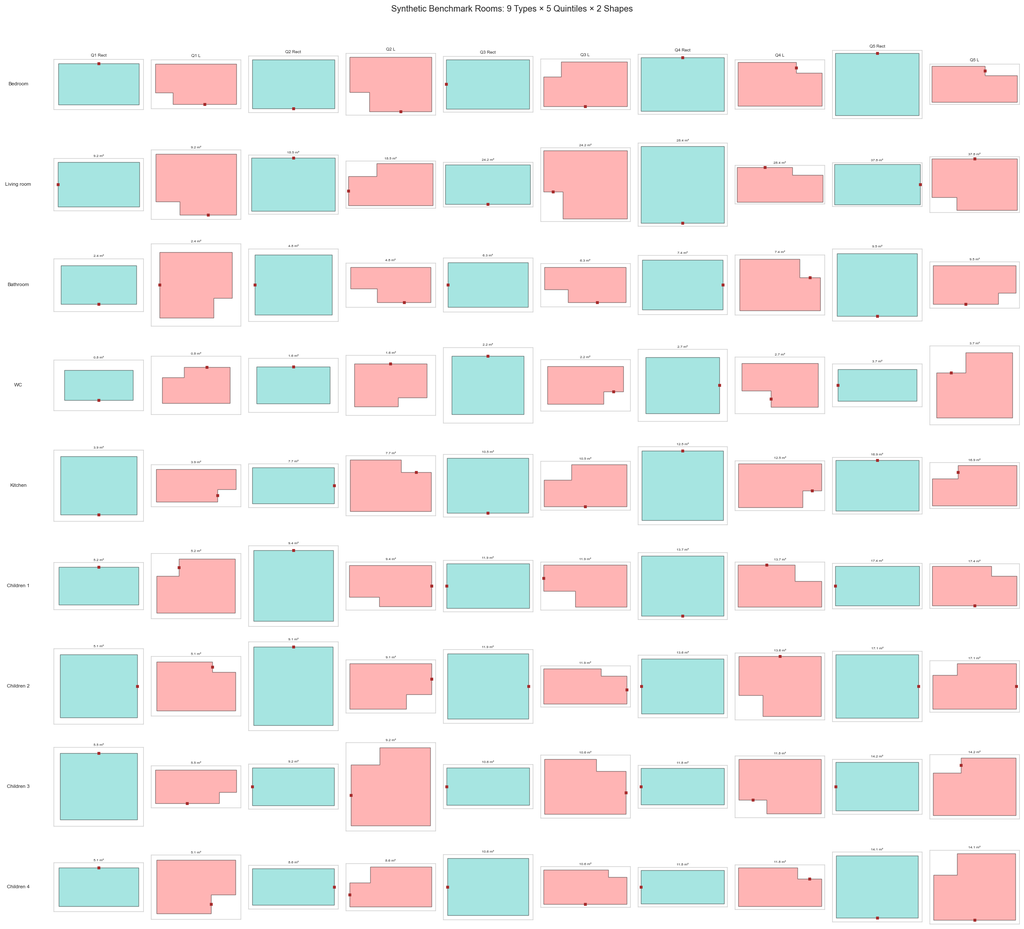

```python
with open(PROJECT_ROOT / "tests" / "phase9_benchmark.json") as f:
    benchmark_rooms = json.load(f)


def plot_room(ax, room_dict):
    poly = np.array(room_dict["polygon"])
    door = np.array(room_dict["door"])
    color = "#4ECDC4" if room_dict["shape"] == "rect" else "#FF6B6B"
    patch = MplPolygon(poly[:-1], closed=True, facecolor=color, edgecolor="black",
                        linewidth=0.8, alpha=0.5)
    ax.add_patch(patch)
    ax.plot(door[0], door[1], "s", color="brown", markersize=3, zorder=5)
    x, y = poly[:, 0], poly[:, 1]
    area_val = 0.5 * abs(float(np.sum(x[:-1] * y[1:] - x[1:] * y[:-1])))
    ax.set_aspect("equal")
    ax.set_xlim(poly[:, 0].min() - 0.2, poly[:, 0].max() + 0.2)
    ax.set_ylim(poly[:, 1].min() - 0.2, poly[:, 1].max() + 0.2)
    ax.set_title(f"{area_val:.1f} m²", fontsize=5, pad=2)


# Organize by (type_idx, quintile, shape)
grid = {}
for r in benchmark_rooms:
    parts = r["name"].split("_")
    q_str = [p for p in parts if p.startswith("q")][0]
    q = int(q_str[1]) - 1
    ti = ROOM_TYPE_TO_IDX[r["room_type"]]
    grid.setdefault((ti, q, r["shape"]), []).append(r)

n_types = len(ROOM_TYPES)
fig, axes = plt.subplots(n_types, 10, figsize=(20, n_types * 2))

for ti, rt in enumerate(ROOM_TYPES):
    for q in range(5):
        for si, shape in enumerate(["rect", "lshape"]):
            col = q * 2 + si
            ax = axes[ti, col]
            rooms_in_cell = grid.get((ti, q, shape), [])
            if rooms_in_cell:
                plot_room(ax, rooms_in_cell[0])
            else:
                ax.text(0.5, 0.5, "N/A", ha="center", va="center", fontsize=6,
                       transform=ax.transAxes)
            ax.set_xticks([])
            ax.set_yticks([])
            if col == 0:
                ax.set_ylabel(rt, fontsize=7, rotation=0, labelpad=50, va="center")
            if ti == 0:
                shape_label = "Rect" if shape == "rect" else "L"
                ax.set_title(f"Q{q+1} {shape_label}", fontsize=6, pad=4)

fig.suptitle("Synthetic Benchmark Rooms: 9 Types × 5 Quintiles × 2 Shapes",
             fontsize=12, y=1.01)
plt.tight_layout()
plt.show()
```

## 4. Speed Results

### 4.1 Python Timing

```python
# Build Room objects for LightGBM
benchmark_room_objs = []
for r in benchmark_rooms:
    poly = np.array(r["polygon"], dtype=np.float64)
    door = np.array(r["door"], dtype=np.float64)
    apt = r.get("apartment_type", "2-Bedroom")
    room = Room(
        polygon=poly, door=door, room_type=r["room_type"],
        room_type_idx=ROOM_TYPE_TO_IDX[r["room_type"]],
        score=None, apartment_type=apt,
        apartment_type_idx=APT_TYPE_TO_IDX[apt],
    )
    benchmark_room_objs.append(room)

n_rooms = len(benchmark_rooms)

# CNN cold-start
_model_cache.clear()
r0 = benchmark_rooms[0]
t0 = time.perf_counter()
_ = predict_score(np.array(r0["polygon"]), np.array(r0["door"]),
                  r0["room_type"], apartment_type=r0.get("apartment_type"))
cnn_cold_ms = (time.perf_counter() - t0) * 1000

# CNN warm (3 runs)
cnn_run_times = []
for run in range(3):
    t0 = time.perf_counter()
    for r in benchmark_rooms:
        _ = predict_score(np.array(r["polygon"]), np.array(r["door"]),
                          r["room_type"], apartment_type=r.get("apartment_type"))
    cnn_run_times.append(time.perf_counter() - t0)
cnn_warm_ms = np.median(cnn_run_times) / n_rooms * 1000

# LightGBM cold-start
t0 = time.perf_counter()
lgbm_model = joblib.load(PROJECT_ROOT / "models" / "baseline_lgbm.joblib")
lgbm_cold_ms = (time.perf_counter() - t0) * 1000

# LightGBM warm (3 runs)
lgbm_run_times = []
for run in range(3):
    t0 = time.perf_counter()
    X = extract_feature_matrix(benchmark_room_objs)
    _ = lgbm_model.predict(X)
    lgbm_run_times.append(time.perf_counter() - t0)
lgbm_warm_ms = np.median(lgbm_run_times) / n_rooms * 1000

print(f"CNN v4:    cold={cnn_cold_ms:.1f} ms, warm={cnn_warm_ms:.2f} ms/room")
print(f"LightGBM:  cold={lgbm_cold_ms:.1f} ms, warm={lgbm_warm_ms:.4f} ms/room")
print(f"Speed ratio (CNN/LGB): {cnn_warm_ms / lgbm_warm_ms:.0f}×")

# Save
python_timing = {
    "n_rooms": n_rooms,
    "cnn_v4": {"cold_start_ms": round(cnn_cold_ms, 2),
               "warm_ms_per_room": round(cnn_warm_ms, 4),
               "warm_total_seconds": [round(t, 4) for t in cnn_run_times]},
    "lgbm": {"cold_start_ms": round(lgbm_cold_ms, 2),
             "warm_ms_per_room": round(lgbm_warm_ms, 4),
             "warm_total_seconds": [round(t, 6) for t in lgbm_run_times]},
}
with open(RESULTS_DIR / "phase9_python_timing.json", "w") as f:
    json.dump(python_timing, f, indent=2)
```

```
CNN v4:    cold=21.4 ms, warm=2.39 ms/room
LightGBM:  cold=42.6 ms, warm=0.0684 ms/room
Speed ratio (CNN/LGB): 35×
```

### 4.2 Speed Comparison Chart

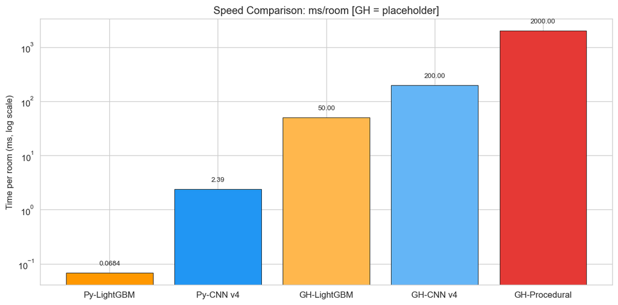

```
⚠ GH timing values are placeholders — update after manual measurement
```

|  | Comparison | ms/room | Baseline | Speed-up |
| --- | --- | --- | --- | --- |
| 0 | GH-LGB vs GH-Proc. | 50.00 | 2000.0 | 40× |
| 1 | GH-CNN vs GH-Proc. | 200.00 | 2000.0 | 10× |
| 2 | Py-LGB vs GH-Proc. | 0.0684 | 2000.0 | 29253× |
| 3 | Py-CNN vs GH-Proc. | 2.39 | 2000.0 | 838× |

```python
# Load GH timing if available
gh_timing_path = RESULTS_DIR / "phase9_gh_timing.json"
if gh_timing_path.exists():
    with open(gh_timing_path) as f:
        gh_timing = json.load(f)
    gh_n = gh_timing["n_rooms"]
    gh_procedural_ms = gh_timing["procedural_total_seconds"] / gh_n * 1000
    gh_cnn_ms = gh_timing["cnn_v4_total_seconds"] / gh_n * 1000
    gh_lgbm_ms = gh_timing["lgbm_total_seconds"] / gh_n * 1000
    gh_data_available = True
else:
    gh_procedural_ms, gh_cnn_ms, gh_lgbm_ms = 2000.0, 200.0, 50.0
    gh_data_available = False

methods = ["Py-LightGBM", "Py-CNN v4", "GH-LightGBM", "GH-CNN v4", "GH-Procedural"]
times_ms = [lgbm_warm_ms, cnn_warm_ms, gh_lgbm_ms, gh_cnn_ms, gh_procedural_ms]
colors = ["#FF9800", "#2196F3", "#FFB74D", "#64B5F6", "#E53935"]

fig, ax = plt.subplots(figsize=(10, 5))
bars = ax.bar(methods, times_ms, color=colors, edgecolor="black", linewidth=0.5)
ax.set_yscale("log")
ax.set_ylabel("Time per room (ms, log scale)")
suffix = "" if gh_data_available else " [GH = placeholder]"
ax.set_title(f"Speed Comparison: ms/room{suffix}")
for bar, t in zip(bars, times_ms):
    label = f"{t:.2f}" if t >= 1 else f"{t:.4f}"
    ax.text(bar.get_x() + bar.get_width()/2, bar.get_height() * 1.3,
            label, ha="center", va="bottom", fontsize=8)
plt.tight_layout()
plt.show()

# Speed-up table
speedup = pd.DataFrame([
    {"Comparison": "GH-LGB vs GH-Proc.", "ms/room": f"{gh_lgbm_ms:.2f}",
     "Baseline": f"{gh_procedural_ms:.1f}", "Speed-up": f"{gh_procedural_ms/gh_lgbm_ms:.0f}×"},
    {"Comparison": "GH-CNN vs GH-Proc.", "ms/room": f"{gh_cnn_ms:.2f}",
     "Baseline": f"{gh_procedural_ms:.1f}", "Speed-up": f"{gh_procedural_ms/gh_cnn_ms:.0f}×"},
    {"Comparison": "Py-LGB vs GH-Proc.", "ms/room": f"{lgbm_warm_ms:.4f}",
     "Baseline": f"{gh_procedural_ms:.1f}", "Speed-up": f"{gh_procedural_ms/lgbm_warm_ms:.0f}×"},
    {"Comparison": "Py-CNN vs GH-Proc.", "ms/room": f"{cnn_warm_ms:.2f}",
     "Baseline": f"{gh_procedural_ms:.1f}", "Speed-up": f"{gh_procedural_ms/cnn_warm_ms:.0f}×"},
])
if not gh_data_available:
    print("⚠ GH timing values are placeholders — update after manual measurement")
speedup
```

### 4.3 Cold-Start Comparison

```python
pd.DataFrame([
    {"Model": "CNN v4", "Cold-start (ms)": f"{cnn_cold_ms:.1f}",
     "Includes": "torch.load() + model construction"},
    {"Model": "LightGBM", "Cold-start (ms)": f"{lgbm_cold_ms:.1f}",
     "Includes": "joblib.load() only"},
])
```

|  | Model | Cold-start (ms) | Includes |
| --- | --- | --- | --- |
| 0 | CNN v4 | 21.4 | torch.load() + model construction |
| 1 | LightGBM | 42.6 | joblib.load() only |

## 5. Accuracy Results

```python
# Load test split
print("Loading training data...")
apts = load_apartments()
splits = assign_splits(apts)
test_rooms = get_rooms_by_split(apts, splits)["test"]
y_true = extract_scores(test_rooms)
print(f"Test set: {len(test_rooms)} rooms")

# LightGBM predictions
X_test = extract_feature_matrix(test_rooms)
y_lgbm = np.clip(lgbm_model.predict(X_test), 0, 100).astype(np.float32)

# CNN v4 predictions
print("CNN v4 predictions...")
y_cnn = []
for i, room in enumerate(test_rooms):
    y_cnn.append(predict_score(room.polygon, room.door, room.room_type,
                               apartment_type=room.apartment_type))
    if (i + 1) % 1000 == 0:
        print(f"  {i+1}/{len(test_rooms)}")
y_cnn = np.array(y_cnn, dtype=np.float32)
print("Done")
```

```
Loading training data...
```

```
Test set: 4594 rooms
CNN v4 predictions...
```

```
  1000/4594
```

```
  2000/4594
```

```
  3000/4594
```

```
  4000/4594
```

```
Done
```

### 5.1 Overall Metrics

```python
def metrics(y_true, y_pred):
    return {
        "MAE": mean_absolute_error(y_true, y_pred),
        "RMSE": np.sqrt(mean_squared_error(y_true, y_pred)),
        "R²": r2_score(y_true, y_pred),
    }

m_cnn = metrics(y_true, y_cnn)
m_lgbm = metrics(y_true, y_lgbm)

pd.DataFrame([
    {"Model": "CNN v4", **{k: f"{v:.4f}" if k == "R²" else f"{v:.2f}" for k, v in m_cnn.items()}},
    {"Model": "LightGBM", **{k: f"{v:.4f}" if k == "R²" else f"{v:.2f}" for k, v in m_lgbm.items()}},
])
```

|  | Model | MAE | RMSE | R² |
| --- | --- | --- | --- | --- |
| 0 | CNN v4 | 9.69 | 16.55 | 0.8507 |
| 1 | LightGBM | 7.58 | 14.39 | 0.8870 |

### 5.2 Predicted vs Actual (R² Scatter)

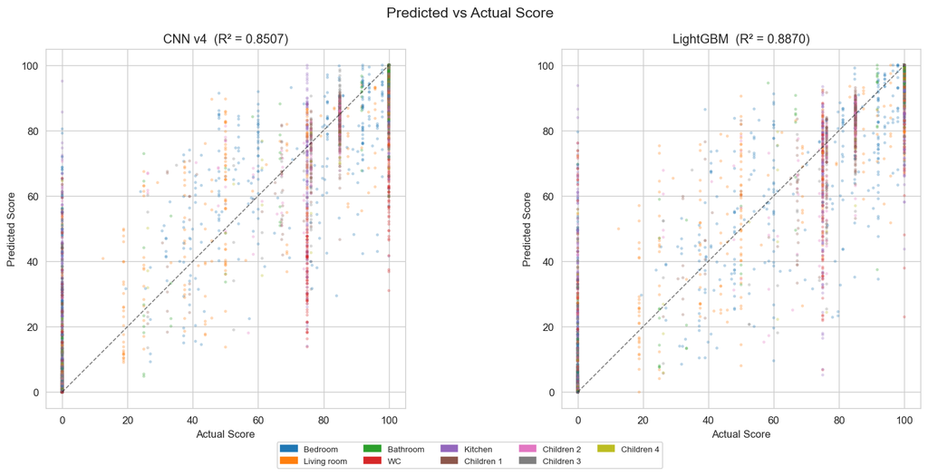

```python
type_colors = dict(zip(ROOM_TYPES, sns.color_palette("tab10", len(ROOM_TYPES))))
room_colors = [type_colors[r.room_type] for r in test_rooms]

fig, (ax1, ax2) = plt.subplots(1, 2, figsize=(14, 6))
for ax, y_pred, title, m in [(ax1, y_cnn, "CNN v4", m_cnn), (ax2, y_lgbm, "LightGBM", m_lgbm)]:
    ax.scatter(y_true, y_pred, c=room_colors, alpha=0.3, s=8, edgecolors="none")
    ax.plot([0, 100], [0, 100], "k--", lw=1, alpha=0.5)
    ax.set_xlabel("Actual Score")
    ax.set_ylabel("Predicted Score")
    ax.set_title(f"{title}  (R² = {m['R²']:.4f})")
    ax.set_xlim(-5, 105)
    ax.set_ylim(-5, 105)
    ax.set_aspect("equal")

handles = [mpatches.Patch(color=type_colors[rt], label=rt) for rt in ROOM_TYPES]
fig.legend(handles=handles, loc="lower center", ncol=5, fontsize=8, bbox_to_anchor=(0.5, -0.05))
fig.suptitle("Predicted vs Actual Score", fontsize=14)
plt.tight_layout()
plt.show()
```

### 5.3 Residual Plot

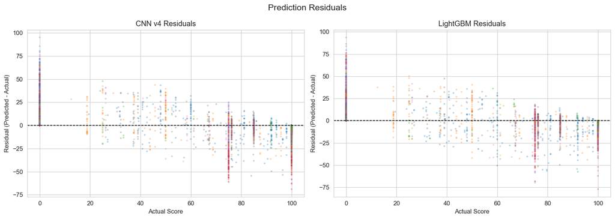

```python
fig, (ax1, ax2) = plt.subplots(1, 2, figsize=(14, 5))
for ax, y_pred, title in [(ax1, y_cnn, "CNN v4"), (ax2, y_lgbm, "LightGBM")]:
    ax.scatter(y_true, y_pred - y_true, c=room_colors, alpha=0.3, s=8, edgecolors="none")
    ax.axhline(0, color="black", lw=1, ls="--")
    ax.set_xlabel("Actual Score")
    ax.set_ylabel("Residual (Predicted - Actual)")
    ax.set_title(f"{title} Residuals")
    ax.set_xlim(-5, 105)
fig.suptitle("Prediction Residuals", fontsize=14)
plt.tight_layout()
plt.show()
```

### 5.4 Per-Room-Type MAE

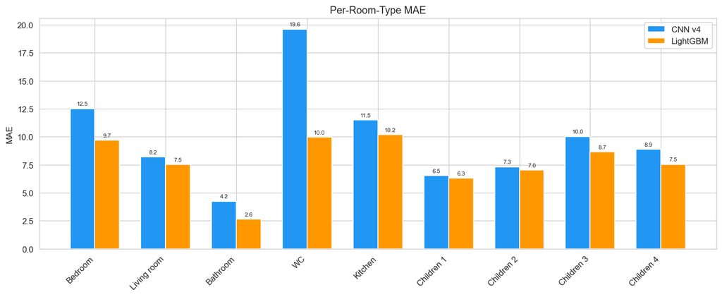

```python
room_types_arr = np.array([r.room_type for r in test_rooms])
per_type = []
for rt in ROOM_TYPES:
    mask = room_types_arr == rt
    n = mask.sum()
    if n == 0: continue
    per_type.append({
        "Room Type": rt, "N": int(n),
        "CNN MAE": mean_absolute_error(y_true[mask], y_cnn[mask]),
        "LGB MAE": mean_absolute_error(y_true[mask], y_lgbm[mask]),
        "CNN R²": r2_score(y_true[mask], y_cnn[mask]) if n > 1 else float('nan'),
        "LGB R²": r2_score(y_true[mask], y_lgbm[mask]) if n > 1 else float('nan'),
    })

rt_names = [d["Room Type"] for d in per_type]
x = np.arange(len(rt_names))
width = 0.35

fig, ax = plt.subplots(figsize=(12, 5))
bars1 = ax.bar(x - width/2, [d["CNN MAE"] for d in per_type], width,
               label="CNN v4", color="#2196F3")
bars2 = ax.bar(x + width/2, [d["LGB MAE"] for d in per_type], width,
               label="LightGBM", color="#FF9800")
ax.set_ylabel("MAE")
ax.set_title("Per-Room-Type MAE")
ax.set_xticks(x)
ax.set_xticklabels(rt_names, rotation=45, ha="right")
ax.legend()
for bars in [bars1, bars2]:
    for bar in bars:
        ax.text(bar.get_x() + bar.get_width()/2, bar.get_height() + 0.2,
                f"{bar.get_height():.1f}", ha="center", va="bottom", fontsize=7)
plt.tight_layout()
plt.show()
```

### 5.5 Error Distribution

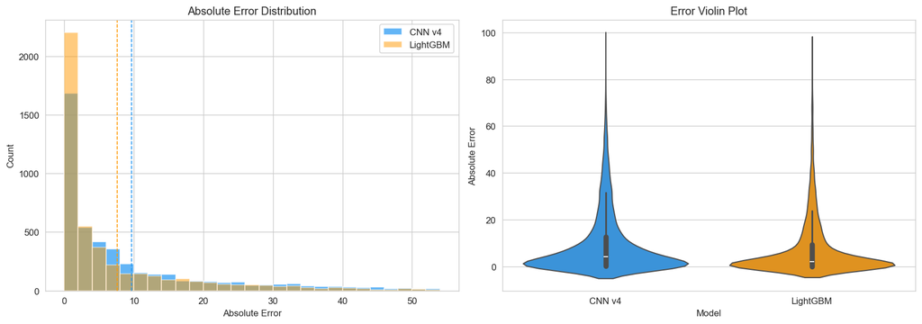

```
CNN v4: median=4.3, P90=29.6, P95=39.9
LightGBM: median=2.3, P90=23.2, P95=33.8
```

```python
abs_err_cnn = np.abs(y_cnn - y_true)
abs_err_lgbm = np.abs(y_lgbm - y_true)

fig, (ax1, ax2) = plt.subplots(1, 2, figsize=(14, 5))

bins = np.arange(0, 55, 2)
ax1.hist(abs_err_cnn, bins=bins, alpha=0.7, color="#2196F3", label="CNN v4")
ax1.hist(abs_err_lgbm, bins=bins, alpha=0.5, color="#FF9800", label="LightGBM")
ax1.axvline(m_cnn["MAE"], color="#2196F3", ls="--", lw=1)
ax1.axvline(m_lgbm["MAE"], color="#FF9800", ls="--", lw=1)
ax1.set_xlabel("Absolute Error")
ax1.set_ylabel("Count")
ax1.set_title("Absolute Error Distribution")
ax1.legend()

df_err = pd.DataFrame({
    "Absolute Error": np.concatenate([abs_err_cnn, abs_err_lgbm]),
    "Model": ["CNN v4"] * len(abs_err_cnn) + ["LightGBM"] * len(abs_err_lgbm),
})
sns.violinplot(data=df_err, x="Model", y="Absolute Error", ax=ax2,
               palette={"CNN v4": "#2196F3", "LightGBM": "#FF9800"})
ax2.set_title("Error Violin Plot")

plt.tight_layout()
plt.show()

for name, err in [("CNN v4", abs_err_cnn), ("LightGBM", abs_err_lgbm)]:
    print(f"{name}: median={np.median(err):.1f}, P90={np.percentile(err, 90):.1f}, "
          f"P95={np.percentile(err, 95):.1f}")
```

### 5.6 Per-Room-Type R² Table

```python
pd.DataFrame([{
    "Room Type": d["Room Type"], "N": d["N"],
    "CNN R²": f"{d['CNN R²']:.4f}", "LGB R²": f"{d['LGB R²']:.4f}",
    "CNN MAE": f"{d['CNN MAE']:.2f}", "LGB MAE": f"{d['LGB MAE']:.2f}",
} for d in per_type])
```

|  | Room Type | N | CNN R² | LGB R² | CNN MAE | LGB MAE |
| --- | --- | --- | --- | --- | --- | --- |
| 0 | Bedroom | 744 | 0.7957 | 0.8617 | 12.52 | 9.70 |
| 1 | Living room | 750 | 0.9053 | 0.9054 | 8.21 | 7.52 |
| 2 | Bathroom | 833 | 0.9482 | 0.9727 | 4.24 | 2.65 |
| 3 | WC | 429 | 0.6407 | 0.8251 | 19.61 | 9.97 |
| 4 | Kitchen | 833 | 0.8271 | 0.8358 | 11.51 | 10.18 |
| 5 | Children 1 | 494 | 0.9096 | 0.9048 | 6.53 | 6.30 |
| 6 | Children 2 | 286 | 0.8620 | 0.8821 | 7.31 | 7.03 |
| 7 | Children 3 | 162 | 0.8326 | 0.8399 | 10.03 | 8.65 |
| 8 | Children 4 | 63 | 0.8627 | 0.8709 | 8.88 | 7.54 |

## 6. Prediction Galleries

### 6.1 Best 20 Predictions (CNN v4)

Rooms where the surrogate prediction is closest to the procedural score.

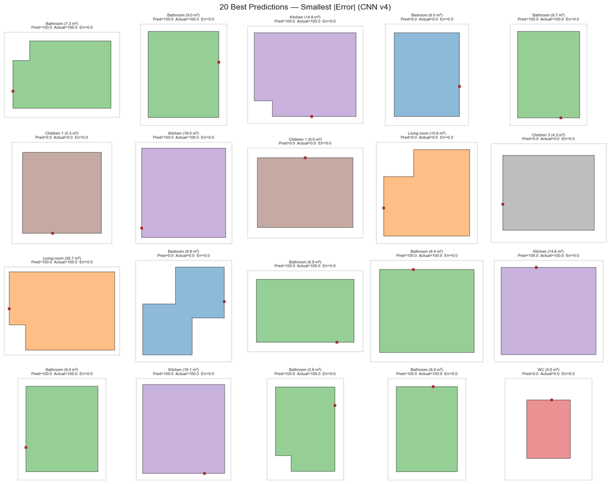

```python
def plot_gallery(rooms, y_true_arr, y_pred_arr, title, n=20):
    ncols = 5
    nrows = (n + ncols - 1) // ncols
    fig, axes = plt.subplots(nrows, ncols, figsize=(15, nrows * 3))
    axes = axes.flatten()
    for i in range(n):
        ax = axes[i]
        room = rooms[i]
        poly, door = room.polygon, room.door
        actual, predicted = y_true_arr[i], y_pred_arr[i]
        # Compute area via shoelace
        x, y = poly[:, 0], poly[:, 1]
        area_val = 0.5 * abs(float(np.sum(x[:-1] * y[1:] - x[1:] * y[:-1])))
        color = type_colors[room.room_type]
        patch = MplPolygon(poly[:-1], closed=True, facecolor=color,
                           edgecolor="black", linewidth=1, alpha=0.5)
        ax.add_patch(patch)
        ax.plot(door[0], door[1], "s", color="brown", markersize=4, zorder=5)
        ax.set_aspect("equal")
        pad = 0.3
        ax.set_xlim(poly[:, 0].min() - pad, poly[:, 0].max() + pad)
        ax.set_ylim(poly[:, 1].min() - pad, poly[:, 1].max() + pad)
        ax.set_xticks([])
        ax.set_yticks([])
        ax.set_title(
            f"{room.room_type} ({area_val:.1f} m²)\n"
            f"Pred={predicted:.1f}  Actual={actual:.1f}  Err={abs(predicted-actual):.1f}",
            fontsize=7,
        )
    for i in range(n, len(axes)):
        axes[i].set_visible(False)
    fig.suptitle(title, fontsize=14)
    plt.tight_layout()
    plt.show()


abs_errors = np.abs(y_cnn - y_true)
sorted_idx = np.argsort(abs_errors)

best_idx = sorted_idx[:20]
plot_gallery([test_rooms[i] for i in best_idx], y_true[best_idx], y_cnn[best_idx],
             "20 Best Predictions — Smallest |Error| (CNN v4)")
```

### 6.2 Worst 20 Predictions (CNN v4)

Rooms where the surrogate prediction deviates most from the procedural score. These reveal failure modes.

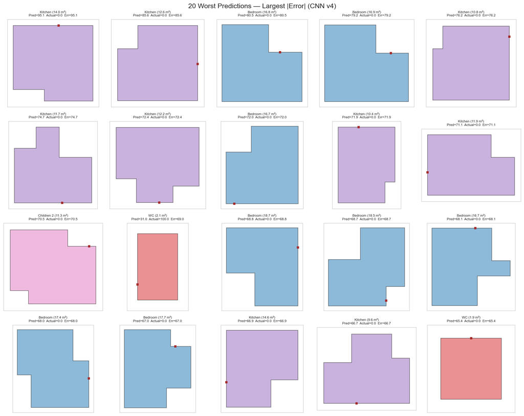

```python
worst_idx = sorted_idx[-20:][::-1]
plot_gallery([test_rooms[i] for i in worst_idx], y_true[worst_idx], y_cnn[worst_idx],
             "20 Worst Predictions — Largest |Error| (CNN v4)")
```

## 8. Recommendation

**For RL reward function: Use LightGBM in Python.**

**Caveats:**

- Both surrogates inherit the biases of the procedural furnisher training data
- Performance on room geometries outside training distribution is unknown
- The 8-point MAE means the surrogate reward will sometimes disagree with the procedural furnisher, but this level of noise is acceptable for RL gradient signal